# Project: TMDb Data Analysis

- Introduction
- Data Wrangling
- Exploratory Data Analysis
- Conclusions

## Introduction

### Dataset Description

This is a dataset containing information on 10,000 movies collected from The Movie Database(TMDb).

The Columns (and their functions) in this dataset are listed below:

id:This acts as an index for the dataset

imdb_id: The Movie's identification on IMDB

popularity: This ranks the popularity of a movie

budget: The amount spent for the movie's production,(currency: USD)

revenue: Toatal amount of money generated from the movie (currency : USD)

original_title: Official title of the movie

cast: List of Actors/Actresses that take up a role in the movie

homepage: The website for details and more information on the movie

director: The name of the movie's director

tagline: A sentence used to get someone interested in the movie

keywords: Keywords related to the movie

overview: Brief Synopsis on the movie

runtime: Full lenght of the movie (measured in minutes)

genres: The different categories that the movie can be fit into

production_companies: The companies that produced/worked on/were involved in the movie

release_date: The Month/Day/Year that the movie was released

vote_count: Number of times the movie has been voted/rated

vote_average: Average/Mean vote the movie has received

release_year: The year in which the movie was released

budget_adj: The total budget of the movie, adjusted to the inflation and currency value of 2010 (currency : USD)

revenue_adj: The total revenue generated from the movie, adjusted to the inflation and currency value of 2010 (currency : USD)

### Question(s) for Analysis

I will be investigating the trends bwtween a movies' popularity, its voting average, release year and how this impacts the revenue generated.

These questions will be used to create conclusions on the investigation:

1) What is the average popularity value for a movie?

2) What is the range for profit genrated from the movies?

3) What is the average runtime for a movie?

4) Does the genre of the movie impact the amount of profit generated?

5) Does the average popularity of movies increase with time?

6) Is there a relationship between the vote average and profits generated?

7) Which decade has the greatest amount of profits?

```python
import pandas as pd
import matplotlib.pyplot as plt
import numpy as np

%matplotlib inline
```

```python
# Upgrade pandas to use dataframe.explode() function.
!pip install --upgrade pandas==0.25.0
```

## Data Wrangling

### General Properties

```python
#Load the dataset
df = pd.read_csv("tmdb-movies.csv")
df.head()
```

|  | id | imdb_id | popularity | budget | revenue | original_title | cast | homepage | director | tagline | ... | overview | runtime | genres | production_companies | release_date | vote_count | vote_average | release_year | budget_adj | revenue_adj |
| --- | --- | --- | --- | --- | --- | --- | --- | --- | --- | --- | --- | --- | --- | --- | --- | --- | --- | --- | --- | --- | --- |
| 0 | 135397 | tt0369610 | 32.985763 | 150000000 | 1513528810 | Jurassic World | Chris Pratt\|Bryce Dallas Howard\|Irrfan Khan\|Vi... | http://www.jurassicworld.com/ | Colin Trevorrow | The park is open. | ... | Twenty-two years after the events of Jurassic ... | 124 | Action\|Adventure\|Science Fiction\|Thriller | Universal Studios\|Amblin Entertainment\|Legenda... | 6/9/15 | 5562 | 6.5 | 2015 | 1.379999e+08 | 1.392446e+09 |
| 1 | 76341 | tt1392190 | 28.419936 | 150000000 | 378436354 | Mad Max: Fury Road | Tom Hardy\|Charlize Theron\|Hugh Keays-Byrne\|Nic... | http://www.madmaxmovie.com/ | George Miller | What a Lovely Day. | ... | An apocalyptic story set in the furthest reach... | 120 | Action\|Adventure\|Science Fiction\|Thriller | Village Roadshow Pictures\|Kennedy Miller Produ... | 5/13/15 | 6185 | 7.1 | 2015 | 1.379999e+08 | 3.481613e+08 |
| 2 | 262500 | tt2908446 | 13.112507 | 110000000 | 295238201 | Insurgent | Shailene Woodley\|Theo James\|Kate Winslet\|Ansel... | http://www.thedivergentseries.movie/#insurgent | Robert Schwentke | One Choice Can Destroy You | ... | Beatrice Prior must confront her inner demons ... | 119 | Adventure\|Science Fiction\|Thriller | Summit Entertainment\|Mandeville Films\|Red Wago... | 3/18/15 | 2480 | 6.3 | 2015 | 1.012000e+08 | 2.716190e+08 |
| 3 | 140607 | tt2488496 | 11.173104 | 200000000 | 2068178225 | Star Wars: The Force Awakens | Harrison Ford\|Mark Hamill\|Carrie Fisher\|Adam D... | http://www.starwars.com/films/star-wars-episod... | J.J. Abrams | Every generation has a story. | ... | Thirty years after defeating the Galactic Empi... | 136 | Action\|Adventure\|Science Fiction\|Fantasy | Lucasfilm\|Truenorth Productions\|Bad Robot | 12/15/15 | 5292 | 7.5 | 2015 | 1.839999e+08 | 1.902723e+09 |
| 4 | 168259 | tt2820852 | 9.335014 | 190000000 | 1506249360 | Furious 7 | Vin Diesel\|Paul Walker\|Jason Statham\|Michelle ... | http://www.furious7.com/ | James Wan | Vengeance Hits Home | ... | Deckard Shaw seeks revenge against Dominic Tor... | 137 | Action\|Crime\|Thriller | Universal Pictures\|Original Film\|Media Rights ... | 4/1/15 | 2947 | 7.3 | 2015 | 1.747999e+08 | 1.385749e+09 |

5 rows × 21 columns

```python
#Check the shape
df.shape
```

```
(10866, 21)
```

```python
#Check for non-null cells
df.info()
```

```
<class 'pandas.core.frame.DataFrame'>
RangeIndex: 10866 entries, 0 to 10865
Data columns (total 21 columns):
 #   Column                Non-Null Count  Dtype
---  ------                --------------  -----
 0   id                    10866 non-null  int64
 1   imdb_id               10856 non-null  object
 2   popularity            10866 non-null  float64
 3   budget                10866 non-null  int64
 4   revenue               10866 non-null  int64
 5   original_title        10866 non-null  object
 6   cast                  10790 non-null  object
 7   homepage              2936 non-null   object
 8   director              10822 non-null  object
 9   tagline               8042 non-null   object
 10  keywords              9373 non-null   object
 11  overview              10862 non-null  object
 12  runtime               10866 non-null  int64
 13  genres                10843 non-null  object
 14  production_companies  9836 non-null   object
 15  release_date          10866 non-null  object
 16  vote_count            10866 non-null  int64
 17  vote_average          10866 non-null  float64
 18  release_year          10866 non-null  int64
 19  budget_adj            10866 non-null  float64
 20  revenue_adj           10866 non-null  float64
dtypes: float64(4), int64(6), object(11)
memory usage: 1.7+ MB
```

```python
#Check for statistical details
df.describe()
```

|  | id | popularity | budget | revenue | runtime | vote_count | vote_average | release_year | budget_adj | revenue_adj |
| --- | --- | --- | --- | --- | --- | --- | --- | --- | --- | --- |
| count | 10866.000000 | 10866.000000 | 1.086600e+04 | 1.086600e+04 | 10866.000000 | 10866.000000 | 10866.000000 | 10866.000000 | 1.086600e+04 | 1.086600e+04 |
| mean | 66064.177434 | 0.646441 | 1.462570e+07 | 3.982332e+07 | 102.070863 | 217.389748 | 5.974922 | 2001.322658 | 1.755104e+07 | 5.136436e+07 |
| std | 92130.136561 | 1.000185 | 3.091321e+07 | 1.170035e+08 | 31.381405 | 575.619058 | 0.935142 | 12.812941 | 3.430616e+07 | 1.446325e+08 |
| min | 5.000000 | 0.000065 | 0.000000e+00 | 0.000000e+00 | 0.000000 | 10.000000 | 1.500000 | 1960.000000 | 0.000000e+00 | 0.000000e+00 |
| 25% | 10596.250000 | 0.207583 | 0.000000e+00 | 0.000000e+00 | 90.000000 | 17.000000 | 5.400000 | 1995.000000 | 0.000000e+00 | 0.000000e+00 |
| 50% | 20669.000000 | 0.383856 | 0.000000e+00 | 0.000000e+00 | 99.000000 | 38.000000 | 6.000000 | 2006.000000 | 0.000000e+00 | 0.000000e+00 |
| 75% | 75610.000000 | 0.713817 | 1.500000e+07 | 2.400000e+07 | 111.000000 | 145.750000 | 6.600000 | 2011.000000 | 2.085325e+07 | 3.369710e+07 |
| max | 417859.000000 | 32.985763 | 4.250000e+08 | 2.781506e+09 | 900.000000 | 9767.000000 | 9.200000 | 2015.000000 | 4.250000e+08 | 2.827124e+09 |

```python
#Check the number of duplicated rows
sum(df.duplicated())
```

```
1
```

### Data Cleaning

```python
#Drop duplicated cells
df.drop_duplicates(inplace = True)
```

The duplicated cell was dropped to prevent it from altering the results

```python
#Drop unnecesary columns
df.drop(['homepage', 'tagline', 'overview', 'keywords', 'cast','production_companies', 'director', 'imdb_id'], axis = 1, inplace = True)
```

These columns have been dropped because they are not relevant to the questions that are being asked

```python
#The genres column will be filled with "None" values
df['genres'].fillna("None", inplace = True)
```

The missing values in the genres column has been filled with 'None' values to enable us use the column properly

```python
df.info()
```

```
<class 'pandas.core.frame.DataFrame'>
Int64Index: 10865 entries, 0 to 10865
Data columns (total 13 columns):
 #   Column          Non-Null Count  Dtype
---  ------          --------------  -----
 0   id              10865 non-null  int64
 1   popularity      10865 non-null  float64
 2   budget          10865 non-null  int64
 3   revenue         10865 non-null  int64
 4   original_title  10865 non-null  object
 5   runtime         10865 non-null  int64
 6   genres          10865 non-null  object
 7   release_date    10865 non-null  object
 8   vote_count      10865 non-null  int64
 9   vote_average    10865 non-null  float64
 10  release_year    10865 non-null  int64
 11  budget_adj      10865 non-null  float64
 12  revenue_adj     10865 non-null  float64
dtypes: float64(4), int64(6), object(3)
memory usage: 1.2+ MB
```

We can see that we have eradicated null columns and made the dataset more suitable for the questions to be answered

## Exploratory Data Analysis

### What is the average popularity value for a movie?

```python
#We calculate the statistical mean for the popularity column to find the average
df["popularity"].mean()
```

```
0.6464455549010583
```

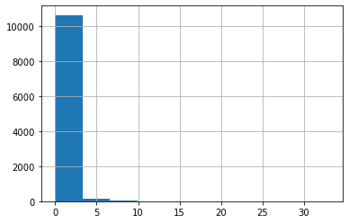

```python
#This is used to plat a chart to better visualize where the average falls
df["popularity"].hist();
```

#### Question Conclusion

We can see that there is a prevalence of low popularity; this because the popularity chart is rightly skewed and the popularity mean is 0.6464455549010583

### What is the range for profit genrated from the movies?

```python
#We derive a profit column by subtracting the budget from the revenue
df["profit_adj"] = df["revenue_adj"] - df['budget_adj']
```

```python
#This produces a tuple of the min and max values
(df["profit_adj"].min(), df["profit_adj"].max())
```

```
(-413912431.0, 2750136650.919176)
```

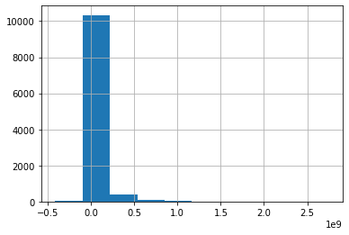

```python
#We use a chart to visualise the range
df["profit_adj"].hist();
```

#### Question Conclusion

We can see here that this tallys with the tuple calculated earlier as it shows that the profit falls between -413912431.0(USD) and 2750136650.919176(USD)

### What is the average runtime for a movie?

```python
#The statistical mean is being calculated to find the average
df["runtime"].mean()
```

```
102.07179015186378
```

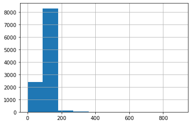

```python
#We use a chart to visualise this averagae and see the predominant part on the runtime values chart
df["runtime"].hist();
```

### Does the genre of the movie impact the amount of profit generated?

```python
#This function will be used to explode columns with '|' to multiple columns
def clean(value):
    df[value].fillna("None", inplace = True)
    df[value] = df[value].apply(lambda x: x.split('|'))
    new = pd.DataFrame.explode(df, value)
    return new
```

```python
#We explode the genres rows with '|' to create a new dataframe
genre_df = clean('genres')
```

```python
#We derive a profit column by subtracting the budget from the revenue
genre_df["profit_adj"] = genre_df["revenue_adj"] - genre_df['budget_adj']
```

```python
#Group the new genre dataframe by genres and find the mean profit for each
profit_genres = genre_df.groupby('genres').mean()['profit_adj']
```

```python
#We see the profits for each genre
profit_genres
```

```
genres
Action             5.879816e+07
Adventure          9.773789e+07
Animation          5.996078e+07
Comedy             3.197669e+07
Crime              3.510290e+07
Documentary        1.634988e+06
Drama              2.556360e+07
Family             6.081282e+07
Fantasy            7.380484e+07
Foreign           -5.948650e+05
History            2.139056e+07
Horror             1.631787e+07
Music              3.366706e+07
Mystery            3.140699e+07
None              -1.220950e+03
Romance            3.254100e+07
Science Fiction    5.745413e+07
TV Movie           5.361383e+04
Thriller           3.460314e+07
War                4.105605e+07
Western            2.160382e+07
Name: profit_adj, dtype: float64
```

```python
#Find the genre with the maximum profit
profit_genres[profit_genres == profit_genres.max()]
```

```
genres
Adventure    9.773789e+07
Name: profit_adj, dtype: float64
```

```python
#Find the genre with the minimum profit
profit_genres[profit_genres == profit_genres.min()]
```

```
genres
Foreign   -594865.037907
Name: profit_adj, dtype: float64
```

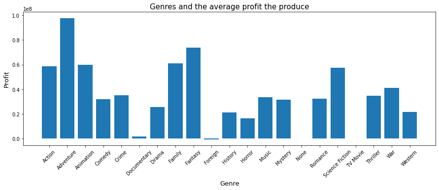

```python
#Plot a chart to see the profits from each genre
plt.figure(figsize = (15,5))
plt.bar(profit_genres.index,profit_genres);
plt.xticks(fontsize = 10, rotation = 45);
plt.xlabel("Genre", fontsize = 13)
plt.ylabel("Profit", fontsize = 13)
plt.title("Genres and the average profit the produce", fontsize = 15);
```

#### Question Conclusion

From the above statistics and visulization, we can see that the Adventure genre produces the greatest amount of profit on average, while the Foreign genre produces the least amount of profit.

### Does the average popularity of movies increase with time?

```python
#We group our main dataframe by the release year and select the popularity column to create a new df
year_pop_df = df.groupby("release_year").mean()["popularity"]
```

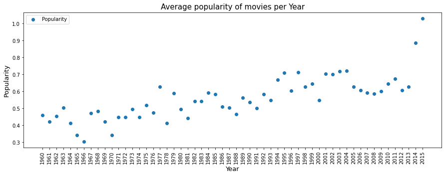

```python
#Since this can be best shown with visualizations, we create a chart to show the change of movie popularity with time
plt.figure(figsize=(15,5))
plt.scatter(year_pop_df.index, year_pop_df, label="Popularity")
plt.xticks(np.arange(df.release_year.unique().min(), df.release_year.unique().max() +1, 1), rotation = 90);
plt.xlabel("Year", fontsize = 13)
plt.ylabel("Popularity", fontsize = 13)
plt.title("Average popularity of movies per Year", fontsize = 15)
plt.legend();
```

#### Question Conclusion

From the above, we can see that the general popularity for movies has increased over time. The chart above shows that recent years have a higher movie popularity than the past years

### Is there a relationship between the vote average and profits generated?

```python
#We reduce the number of points in the vote average to enable us have a clearer visulization
df['levels'] = pd.cut(df['vote_average'], [0,1,2,3,4,5,6,7,8], labels=[1,2,3,4,5,6,7,8])
```

```python
#We group by the levels we created and then select the profit from there
df.groupby('levels').mean()['profit_adj']
```

```
levels
1             NaN
2   -4.254743e+04
3   -1.608304e+06
4   -2.466550e+06
5    9.367726e+05
6    1.860649e+07
7    4.526137e+07
8    8.769718e+07
Name: profit_adj, dtype: float64
```

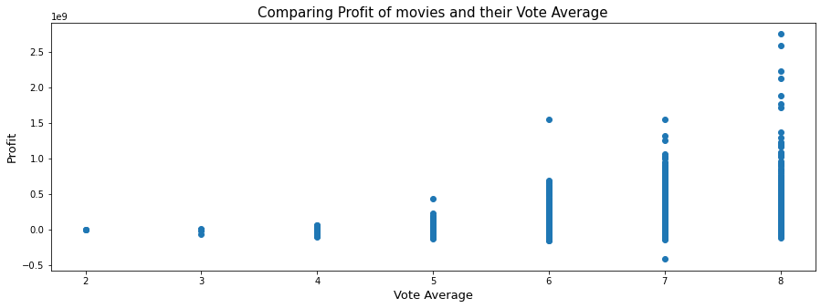

```python
#We create a visualization to see the above more clearly
plt.figure(figsize=(15,5))
plt.scatter(df['levels'], df['profit_adj']);
plt.xlabel("Vote Average", fontsize = 13)
plt.ylabel("Profit", fontsize = 13)
plt.title("Comparing Profit of movies and their Vote Average", fontsize = 15);
```

##### Question Conclusion

From the statistics and chart above, We can see that movies with a vote average of 7 - 8 relatively get higher profits that those with a vote average below 7

### Which decade has the greatest amount of profits?

```python
#We create a column named decade
df['decade'] = pd.cut(df['release_year'], [1950, 1960, 1970, 1980, 1990, 2000,2010,2020], labels=['50s','60s','70s','80s', '90s', '2000s', '2010s'])
```

```python
#We group by the new decade column and select the profit column from the results
df.groupby('decade').mean()['profit_adj']
```

```
decade
50s      2.832787e+07
60s      4.876586e+07
70s      7.067852e+07
80s      4.395847e+07
90s      3.840366e+07
2000s    2.938592e+07
2010s    2.471823e+07
Name: profit_adj, dtype: float64
```

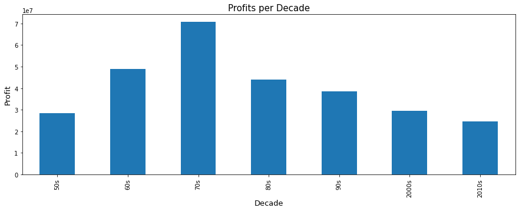

```python
#We create a plot of the new results above to properly visualize it
plt.figure(figsize=(15,5))
df.groupby('decade').mean()['profit_adj'].plot(kind='bar')
plt.xlabel("Decade", fontsize = 13)
plt.ylabel("Profit", fontsize = 13)
plt.title("Profits per Decade", fontsize = 15);
```

#### Question Conclusion

```python
#We create a column named decade for the genre_df dataframe
genre_df['decade'] = pd.cut(genre_df['release_year'], [1950, 1960, 1970, 1980, 1990, 2000,2010,2020], labels=['50s','60s','70s','80s', '90s', '2000s', '2010s'])
```

```python
#We create an updated dataframe to have the top 3 profitable genres; Adventure, Fantasy and Family, and the 3 least profitable
#genres; Documentary, TV Movie and Foreign. It also contains data from only the 60s, 70s and 80s
updated_genre = genre_df[((genre_df['genres'] == 'Adventure') | (genre_df['genres'] =='Family') | (genre_df['genres'] =='Fantasy') | (genre_df['genres'] =='Foreign') | (genre_df['genres'] =='TV Movie') | (genre_df['genres'] =='Documentary')) & ((genre_df['decade'] == '60s') | (genre_df['decade'] == '70s') | (genre_df['decade'] == '80s'))]
```

```python
#A function created to select the values for each genre
def groupings(grouped):
    x = updated_genre.groupby(['decade', 'genres']).mean()['vote_average'].xs(grouped, level = 1)
    return x
s1 = groupings('Adventure')
s2 = groupings('Fantasy')
s3 = groupings('Family')
s4 = groupings('Documentary')
s5 = groupings('TV Movie')
s6 = groupings('Foreign')
```

[figure not shown]

```python
#This is a block of code to produce a visulization withe genres selected
ind = np.arange(len(s1.index))
ins = np.arange(0, 3, 1)
plt.figure(figsize=(10,7))
plt.bar(ind, s1, 0.1, label = 'Adventure')
plt.bar(ind+0.1, s2, 0.1, label = "Fantasy")
plt.bar(ind+0.2, s3, 0.1, label = 'Family')
plt.bar(ind+0.3, s4, 0.1, label = 'Foreign')
plt.bar(ind+0.4, s5, 0.1, label = 'Documentary')
plt.bar(ind+0.5, s6, 0.1, label = 'TV Movie')
tick = (ins)+2.5/2
plt.xticks(tick, ['60s', '70s', '80'])
plt.xlabel("Decades", fontsize = 15)
plt.ylabel('Vote Average', fontsize = 15)
plt.title("Vote Average of the 3 most profitable genres and the 3 most unprofitable genres accross 3 decades", fontsize = 15)
plt.legend();
```

#### Question Conclusion

From the above we can see in the 60s, 70s and 80s the vote average did not determine the amount of money that was generated from the movies; the genres with low profits even have a higher vote average that those with higher profits

## Conclusions

From the above investigation i have come to the following conclusions:

1) There is a prevalence of low popularity and the average popularity is 0.6464455549010583

2) The profit falls between -413912431.0(USD) and 2750136650.919176(USD)

4) The Adventure genre has the been the most profitable over time

5) The average popularity of movies has increased over time

6) Movies with high vote averages genrally have high profits

7) The 70s has the biggest average movie profit

8) In the 60s, 70s and 80s; the vote averages did not determine the movies that were the most profitable and least profitable

Additional information will be beneficial because some movies did not have their genres listed

Limitations:

1) Missing data : A good number of genres and directors were missing

2) A lot of data in the director cells were gibberish

```python
from subprocess import call
call(['python', '-m', 'nbconvert', 'Investigate_a_Dataset.ipynb'])
```

# References : N/A